# NJ Transit Ridership Data

2025-10-11

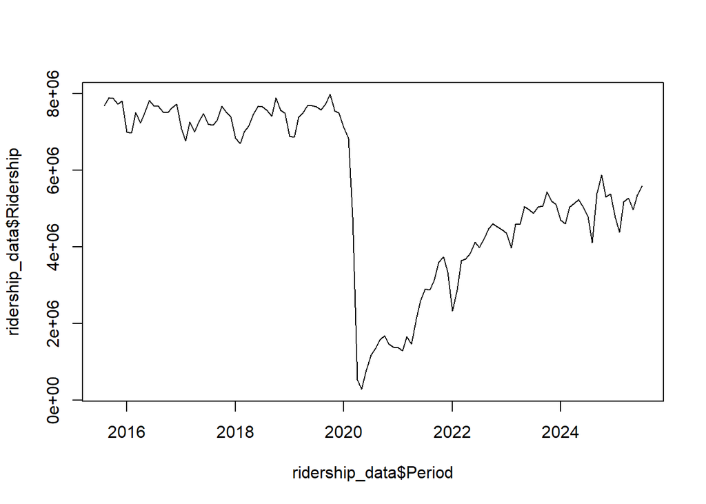

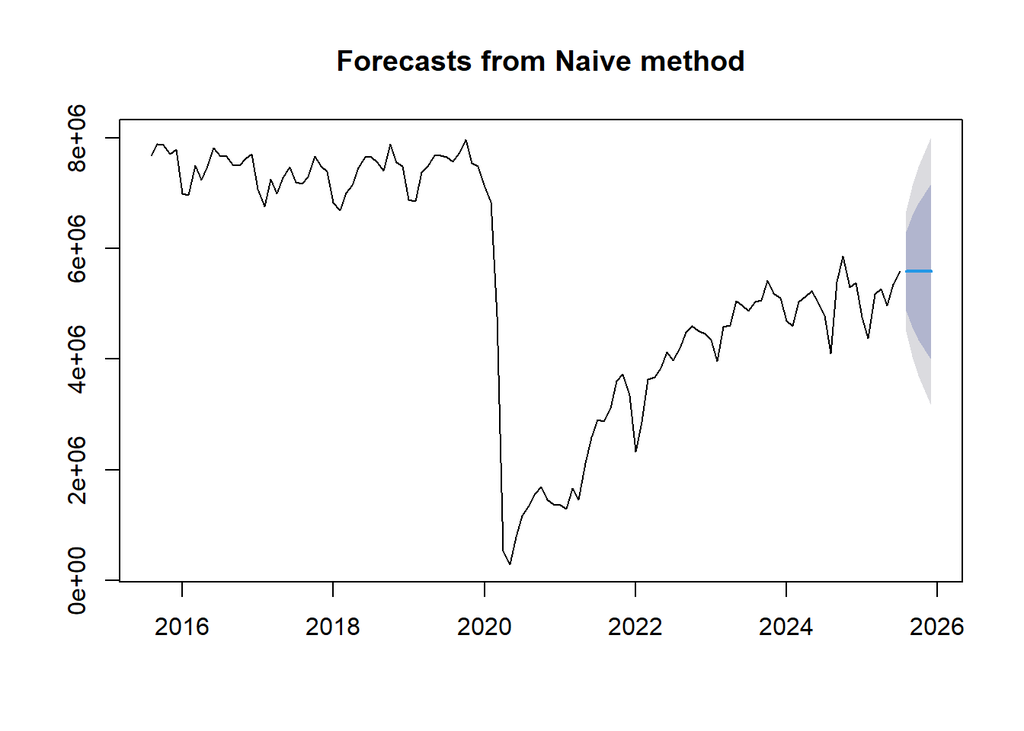

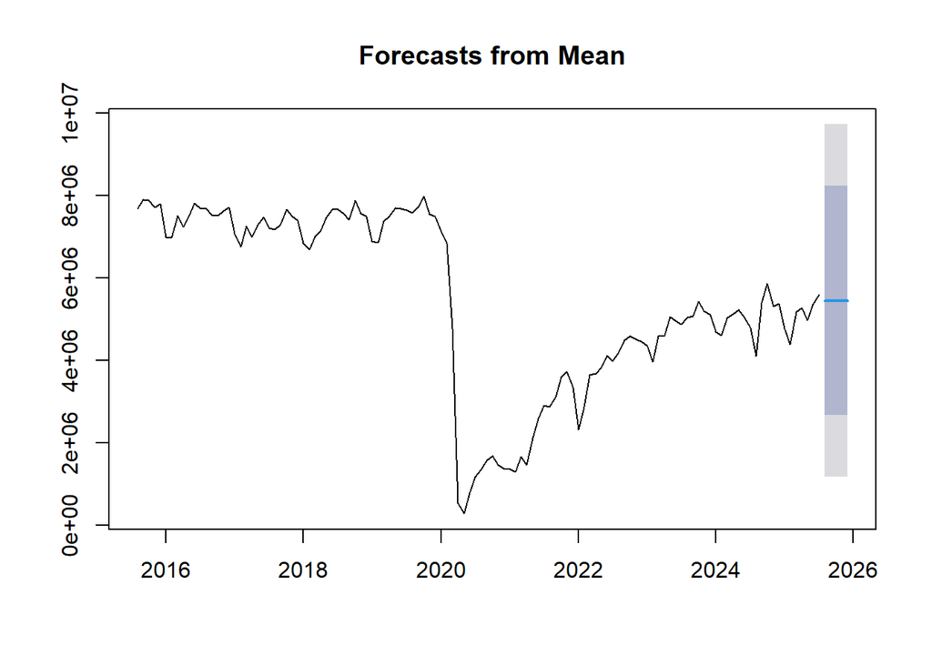

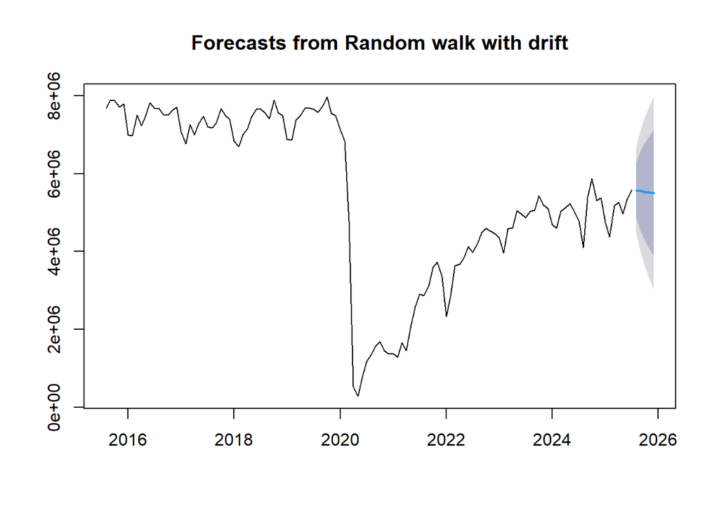

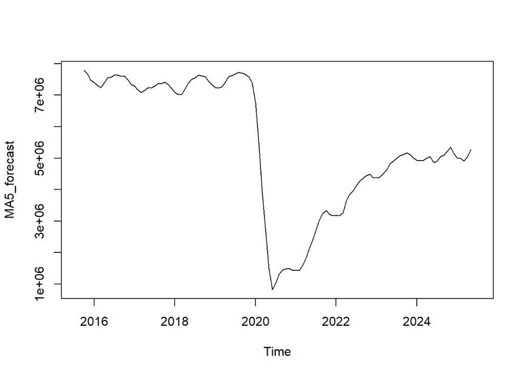

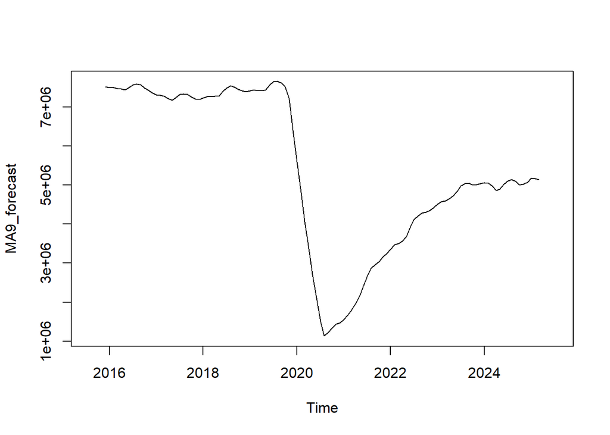

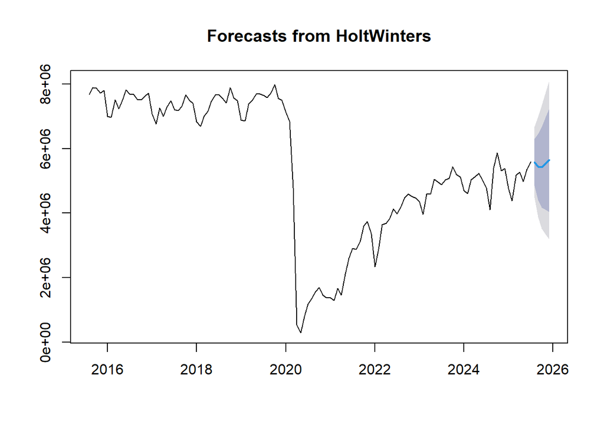

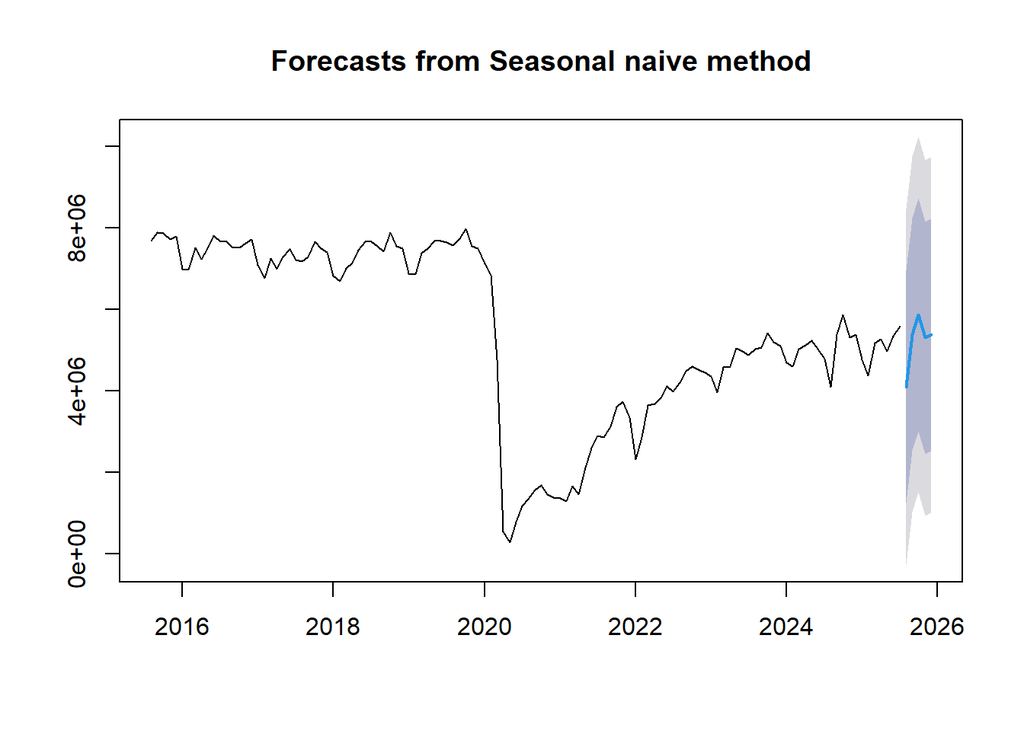

The naive forecast simply follows the data from the previous period to forecast for the current period. For this data, this leaves us with a growing confidence interval around the July 2025 figure.

The mean forecast sets the current forecast equal to the mean of all previous periods. For this data, this means the forecast is equal to the mean so far.

The random walk forecast is based on the data from the previous period, but added with a drift variable. For this data, this leaves us with a growing confidence interval around the July 2025 figure with some drift.

The MA5 forecast is a moving average of the previous 5 periods, focusing on the most recent data. For this data, this resembles the original data but smoothed.

The MA9 forecast is a moving average of the previous 9 periods, focusing on the most recent data but over a longer time than MA5. For this data, this resembles the original data but smoothed- even more than MA5.

The Holt Winters forecast is a an exponential smoothing method that combines the forecast and actual data from the previous period, as well as seasonality. For this data, this returns a confidence interval around the July 2025 figure, but with some curve to account for seasonality.

The seasonal naive forecast is equal to the data from the same point in the previous season. For this data, this means the forecast for the upcoming months is the same as the same time last year.

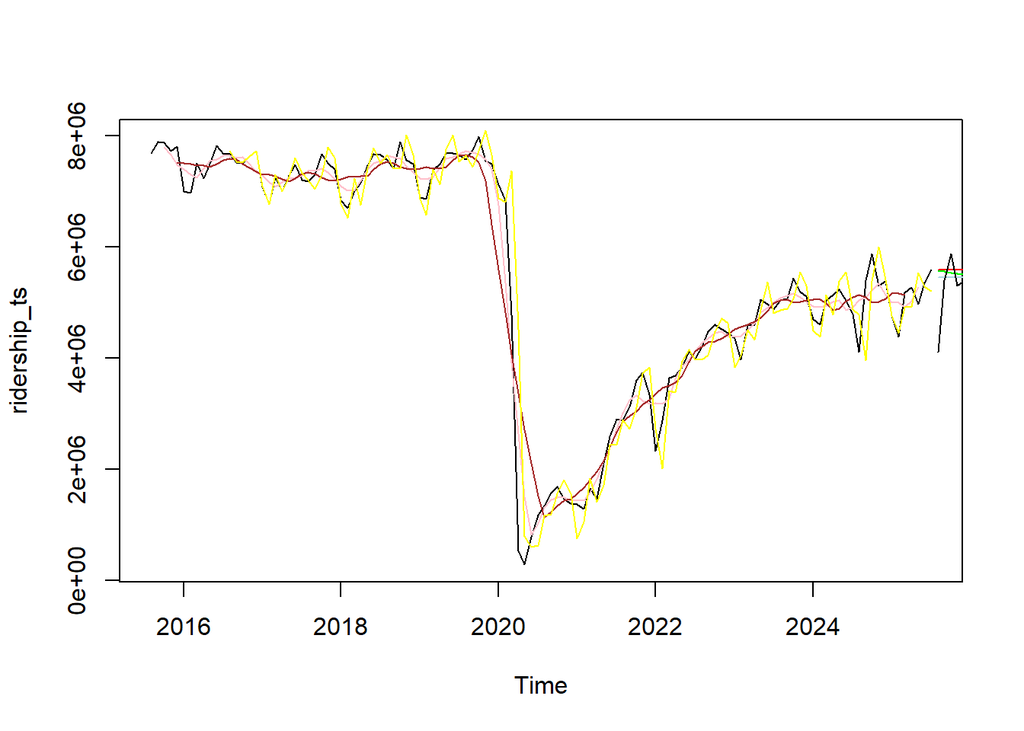

```
##                     ME     RMSE      MAE       MPE     MAPE      MASE      ACF1
## Training set -17585.17 555562.5 317937.3 -6.101577 14.31073 0.2562201 0.2837678
```

```
##                         ME    RMSE     MAE       MPE     MAPE     MASE
## Training set -6.133547e-11 2138613 1813889 -52.23321 76.58082 1.461781
##                   ACF1
## Training set 0.9619956
```

```
##                        ME     RMSE      MAE      MPE     MAPE      MASE
## Training set 1.311114e-10 555284.2 318459.4 -5.60835 14.27608 0.2566408
##                   ACF1
## Training set 0.2837678
```

```
##                    ME     RMSE      MAE      MPE     MAPE       MASE      ACF1
## Training set 2164.158 161629.7 99521.06 1.150887 3.249851 0.08309082 0.2932243
```

```
## Warning in ets(object, lambda = lambda, biasadj = biasadj,
## allow.multiplicative.trend = allow.multiplicative.trend, : Missing values
## encountered. Using longest contiguous portion of time series
```

```
##                     ME    RMSE      MAE       MPE    MAPE       MASE      ACF1
## Training set -2058.793 84388.9 51946.45 0.3854939 1.45602 0.04413082 0.3852671
```

```
##                     ME     RMSE      MAE       MPE    MAPE      MASE      ACF1
## Training set -4581.142 559115.3 295228.1 -6.631696 15.3411 0.2379192 0.3570257
```

```
##                     ME    RMSE     MAE       MPE     MAPE MASE      ACF1
## Training set -269391.9 2226913 1240876 -66.81886 92.55389    1 0.9421399
```

Using MAPE, MA9 appears to be the most accurate model, though R gives a warning of missing values for the Moving Average models. Presumably, this is because they do not have data points for the first few periods. If this is in fact an issue, the rwf model is the most accurate with the lowest MAPE at 14.28.